# Notebook report

## Gamblers ruin

In this simulation a gambler starts with $1,000 (`wealth`). She places a single bet each day of the year and has decided to invest 5% (`perc_invest`) of the available money each time. The probability of winning is 20% (`prob_win`) and if the gambler wins she gets 5 times (`win_mult`) the amount she bet (i.e., the investment).

The challenge in this simulation is that the amount invested (bet) each day depends on whether the gambler won or lost her bet yesterday. To calculate the dynamic wealth, we need to write a custom function (`calc_wealth`). We can *call* the `calc_wealth` function from the `Simulation formulas` input.

The first line in the function creates a vector of length 366 where the first value is the initial investment amount. The other elements of the vector are set to `NA` (i.e., a missing value) because they are, as yet, unknown. We then *loop* through the `win` vector to calculate the available wealth and investment amount for each day.

All required settings are shown in the screenshot below:

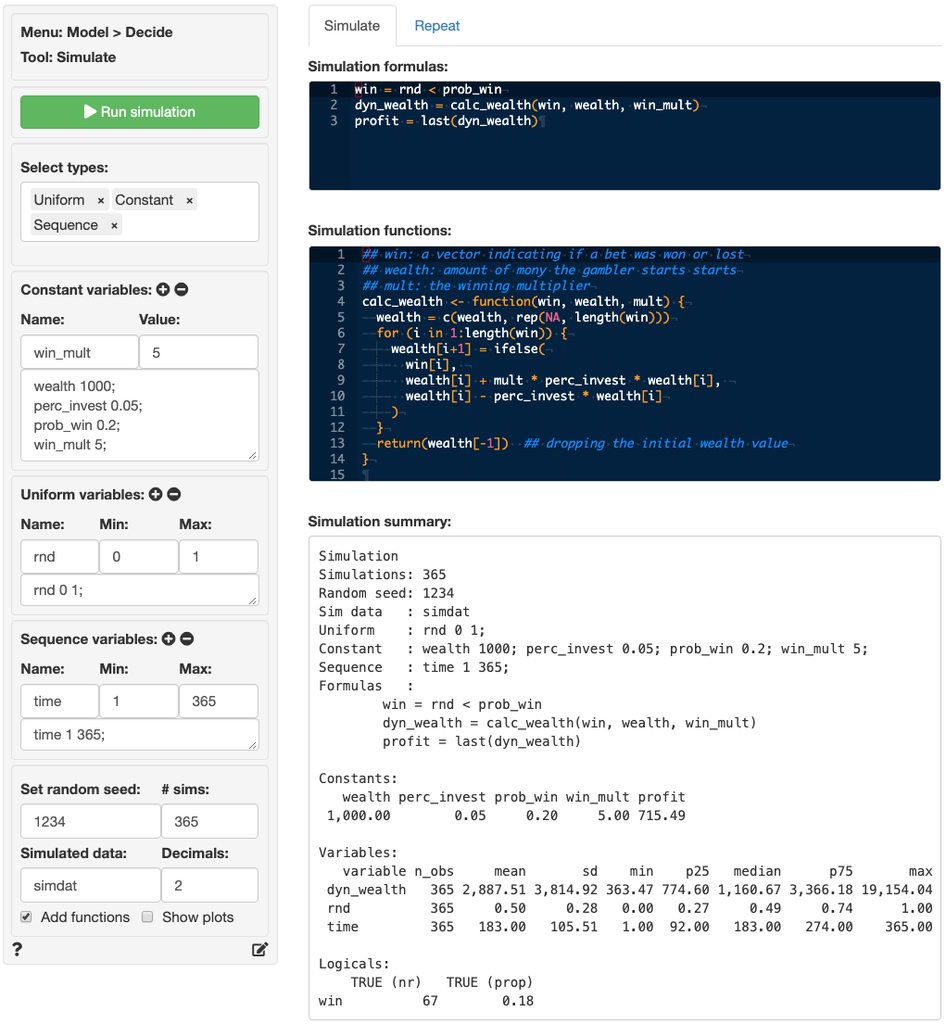

```r
## win: a vector indicating if a bet was won or lost
## wealth: amount of mony the gambler starts starts
## mult: the winning multiplier
calc_wealth <- function(win, wealth, mult) {
  wealth = c(wealth, rep(NA, length(win)))
  for (i in 1:length(win)) {
    wealth[i+1] = ifelse(
      win[i],
      wealth[i] + mult * perc_invest * wealth[i],
      wealth[i] - perc_invest * wealth[i]
    )
  }
  return(wealth[-1])  ## dropping the initial wealth value
}

simdat <- simulater(
  const = c("wealth 1000", "perc_invest 0.05", "prob_win 0.2", "win_mult 5"),
  unif = "rnd 0 1",
  sequ = "time 1 365",
  form = c(
    "win = rnd < prob_win",
    "dyn_wealth = calc_wealth(win, wealth, win_mult)",
    "final = last(dyn_wealth)"
  ),
  funcs = list(calc_wealth = calc_wealth),
  seed = 1234,
  nr = 365
)
summary(simdat, dec = 2)
```

```
Simulation
Simulations: 365
Random seed: 1234
Sim data   : simdat
Uniform    : rnd 0 1
Constant   : wealth 1000; perc_invest 0.05; prob_win 0.2; win_mult 5
Sequence   : time 1 365
Formulas   :
    win = rnd < prob_win
    dyn_wealth = calc_wealth(win, wealth, win_mult)
    final = last(dyn_wealth)

Constants:
   wealth perc_invest prob_win win_mult  final
 1,000.00        0.05     0.20     5.00 715.49

Variables:
   variable n_obs     mean       sd    min    p25   median      p75       max
 dyn_wealth   365 2,887.51 3,814.92 363.47 774.60 1,160.67 3,366.18 19,154.04
 rnd          365     0.50     0.28   0.00   0.27     0.49     0.74      1.00
 time         365   183.00   105.51   1.00  92.00   183.00   274.00    365.00

Logicals:
    TRUE (nr)   TRUE (prop)
win          67        0.18
```

```r
register("simdat")
```

The following plot shows the rise and fall of the gambler’s wealth over the course of the year.

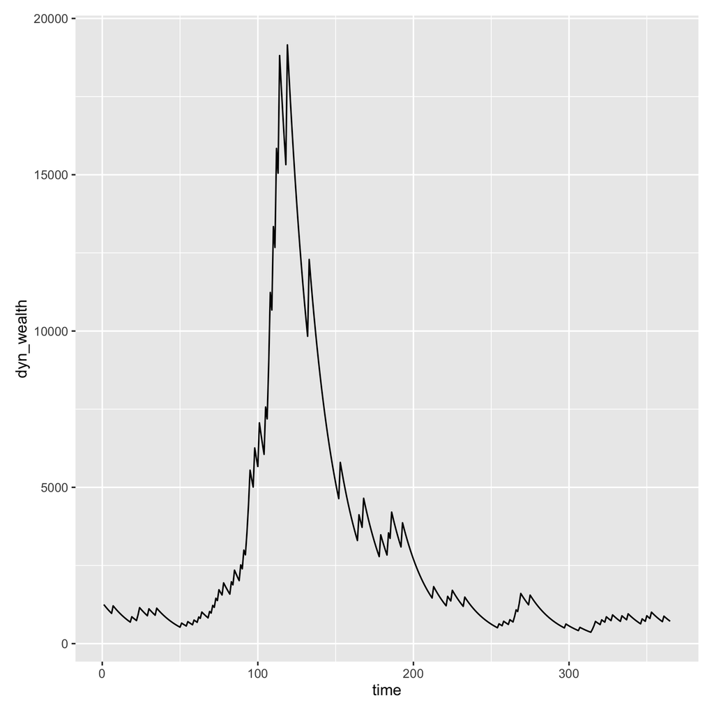

```r
visualize(
  simdat,
  xvar = "time",
  yvar = "dyn_wealth",
  type = "line",
  custom = FALSE
)
```

```r
repdat <- repeater(
  simdat,
  nr = 50,
  vars = "rnd",
  sum_vars = "dyn_wealth",
  byvar = ".rep",
  fun = "last",
  seed = 1234
)
summary(repdat, dec = 2)
```

```
Repeated simulation
Simulations   : 365
Repetitions   : 50
Re-simulated  : rnd
Group by      : Repeat
Function      : last
Random  seed  : 1234
Simulated data: simdat
Repeat data   : repdat

Variables:
        variable n_obs      mean        sd   min    p25   median      p75        max
 dyn_wealth_last    50 13,176.62 29,672.13 26.57 586.70 2,821.87 8,458.30 131,567.01
```

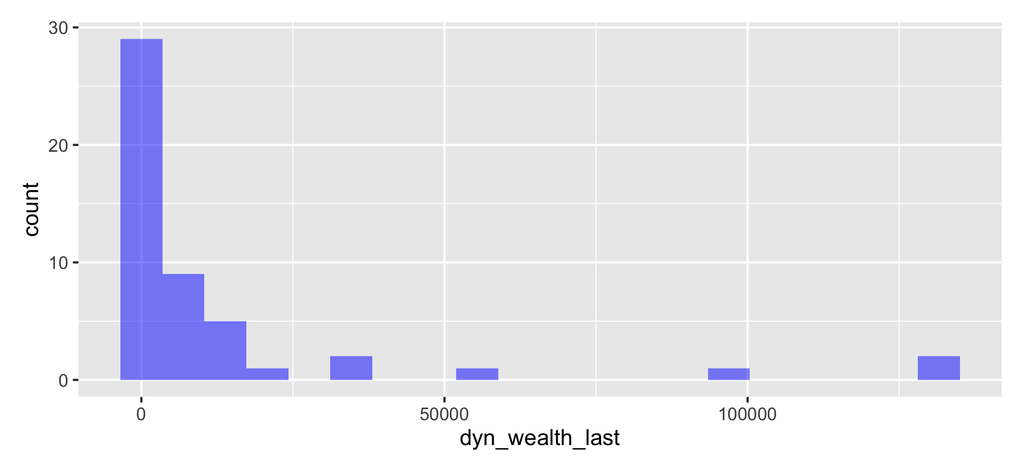

```r
plot(repdat, custom = FALSE)
```

```r
register("repdat")
```